# Sharing Data

03/11/2015

## Credits

The materials for this are cribbed from:

jtleek/datasharing

Most credits go to Dr. Leek for this material.

## Target Audience

- Scientific collaborators who need someone to analyze data for them
- Students or postdocs in scientific disciplines looking for consulting advice
- Junior students whose job it is to collate/clean data sets

## Goals

I want to provide some instruction on the best way to share data to avoid:

- common pitfalls
- sources of delay

in the transition from data collection to data analysis.

## Caveats

The assertions stated here are designed for sharing, manipulation, computational analysis, and data vizualization.

They may not necessarily be the way a data set would be presented in a table for publication or your lab meeting, for example.

But having the data in this form can facilitate this kind of post-processing as well!

## It's hard!

Data cleaning is hard work! You're not going to become an expert overnight.

Make friends with a data scientist, we like making your data better.

## Why?

1. Facilitiates collaboration
2. Allows data visualization
3. Reduces errors
4. Aids reproducibility

## What you should deliver to the analyst

1. The raw data
2. A summarized, [tidy data set](http://vita.had.co.nz/papers/tidy-data.pdf)
3. A code book describing each variable and its values in the summarized data set
4. An explicit and exact recipe you used to go from 1 -> 2,3

## The raw data

- The strange binary file from the qPCR machine
- The unformated Excel file with 10 worksheets the company you contracted with sent you
- The hand-entered numbers you collected looking through a microscope

## How do you know if it's raw?

You know the raw data is in the right format if you:

1. Ran no software on the data
2. Did not manipulate any of the numbers in the data
3. You did not remove any data from the data set
4. You did not summarize the data in any way

## The code book

For almost any data set, the measurements you calculate will need to be described in more detail than you will sneak into the spreadsheet.

1. Information about the variables (including units!) in the data set not contained in the tidy data
2. Information about the summary choices you made
3. Information about the experimental study design you used

## How to code variables

When you put variables into a dataset there are several main categories you will run into:

1. Continuous
2. Ordinal
3. Categorical
4. Dates
5. Entities
6. Misssing
7. Censored

## How to code variables - continuous

Continuous variables are anything measured on a quantitative scale that could be any fractional number

- weight measured in kg
- gene expression level
- concentration of a drug in mol

Put the units in the code book, not in the data! A single column should be represented in the same units.

## How to code variables - ordinal

Ordinal data: fixed, small (< 100) number of ordered levels

- survey responses, e.g., `poor`, `fair`, `good`
- `pass` or `fail` quality control

It's best not to convert continuous variables to ordinal ones in your data, but rather describe it in the code book.

## How to code variables - categorical

Categorical data: unordered, multiple levels

- male or female
- treated (maybe multiple levels), control
- sample type (e.g., different cell lines)

## How to code variables - ordinal and categorical

In general, try to avoid coding categorical or ordinal variables as numbers.

When you enter the value for sex in the tidy data, it should be `male` or `female`.

The ordinal values in the data set should be `poor`, `fair`, and `good`, not `1, 2, 3`.

## How to code variables - dates

Be consistent in the formatting of dates, and be aware of what spreadsheet software can do to them.

- `03-11-2015` is not `11-03-2015`
- `3/11/2015` and `3/11/15` can also be difficult

Also be careful about text columns that can be interpreted as dates (e.g., `Oct4` ends up as `10/4/1900`).

## How to code variables - missing

Missing data are data that are missing and you don't know the mechanism.

Code missing values in a consistent, standardized way (preferably `NA`).

`NA` != `N/A` != `""` != `" "`

Explain this in the code book.

## How to code variables - censored

Censored data: you know the missingness mechanism on some level.

- a measurement being below a detection limit
- equipment or experimental failure
- a patient being lost to follow-up

They should also be coded as `NA` when you don't have the data.

## How to code variables - censored

Add a new column to your data called `VariableNameCensored` which should have values of `TRUE` if censored and `FALSE` if not.

Please, do not impute/make up/throw away missing observations!

## How to code variables - entity names

Whenever possible, use standardized entity names (genes, proteins, reagents, etc.)

When in doubt, check with the trusted naming consortium on how to refer:

- Human - [HGNC](http://www.genenames.org/)
- Mouse - [MGI](http://informatics.jax.org/mgihome/nomen/)
- Drosophila - [FlyBase](http://flybase.org/static_pages/docs/nomenclature/nomenclature3.html)

Example: POU domain, class 5, transcription factor 1 (`POU5F1`) is….

## How to code variables - entity names

Preferably, a unique identifier is the best, if you know you are using a specific gene or protein version:

- Entrez ID (`POU5F1` is [`5460`](http://www.ncbi.nlm.nih.gov/gene/5460))
- Ensembl Transcript ID (transcript 1: [`ENST00000259915`](http://uswest.ensembl.org/Homo_sapiens/Transcript/Summary?db=core;g=ENSG00000204531;r=6:31164337-31180731;t=ENST00000259915))
- SWISS-PROT ID (`POU5F1` is [`Q01860`](http://www.uniprot.org/uniprot/Q01860))
- Sigma Aldrich monoclonal antibody (`POU5F1` is [P0082](http://www.sigmaaldrich.com/catalog/product/sigma/p0082?lang=en&region=US))

## The instruction list/script

You may have heard this before, but [reproducibility is kind of a big deal in computational science](http://www.sciencemag.org/content/334/6060/1226).

That means, when you submit your paper, everyone should be able to exactly replicate the analyses from raw data all the way to final results (including figures displaying data).

## The instruction list/script

The ideal thing for you to do when performing summarization is to create a computer script that takes the raw data as input and produces the data you are sharing as output.

Even if you don't know how to code, you should provide the analyst `psuedocode`:

1. Step 1 - take the raw file, run version 3.1.2 of summarize software with parameters a=1, b=2, c=3
2. Step 2 - run the software separately for each sample
3. Step 3 - take column three of outputfile.out for each sample and that is the corresponding row in the output data set

## What you should expect from the analyst

You should then expect from the statistician:

1. An analysis script that performs each of the analyses (not just instructions)
2. The exact computer code they used to run the analysis
3. All output files/figures they generated

## What you should expect from the analyst

This is the information you will use in the supplement to establish reproducibility and precision of your results.

Each of the steps in the analysis should be clearly explained and you should ask questions when you don't understand what the analyst did.

## What you should expect from the analyst

It is the responsibility of both the statistician and the scientist to understand the statistical analysis.

You may not be able to perform the exact analyses without the statistician's code, but you should be able to explain why the statistician performed each step to a labmate/your principal investigator.

## What you should expect from the analyst

If you're not getting this, ask!

If you're still not getting it, break up with them.

## How to do this

One way: [Synapse](http://www.synapse.org)

You can store and share data, write codebooks and other annotations, and track the steps you used to go from raw data to summarized files (provenance).

[Today's examples](https://www.synapse.org/#!Synapse:syn3270309)

How? Come to the advanced session!

## Tidy data

What is tidy data?

1. Each `variable you measure` should be in a `single column`
2. Each different `observation of that variable` should be in a `single row`
3. There should be `one table` for each "kind" of variable
4. If you have multiple tables, they should include a column in the table that allows them to be linked

## Tidy data

When in doubt, reach out to an analyst; we're here to help!

## Example - 1

```r
## Read in my data from a file
d <- read.csv("data/databetter3.csv")

## Subset my data so I only keep uncensored expression values
dataClean <- subset(d, !(as.logical(expressionCensored)))
```

## Example - summary table

```r
myTable <- dataClean %>%
  ## First, group my data by the gene name and drug amount
  group_by(gene, amount) %>%

  # Compute the mean expression within these groupings
  summarize(meanexpr=mean(expression, na.rm=TRUE)) %>%

  # Convert the data to a table that we can see
  cast(gene ~ amount, value="meanexpr") %>%

  # Make it pretty for my slides
  kable(caption="Mean expression by gene at different drug amounts")
```

## Example - summary table

Mean expression by gene at different drug amounts

| gene | 0 | 0.001 | 0.01 | 0.1 |
| --- | --- | --- | --- | --- |
| NANOG | 11.644506 | 15.06348 | 23.655667 | 55.83678 |
| POU5F1 | 9.741084 | 10.99049 | 9.675218 | 10.34781 |

## Example - plot 1 code

Visualize data per gene and cell line across different drug amounts

```r
p  <- ggplot(dataClean, aes(x=factor(amount), y=expression))
p <- p + geom_boxplot()
p <- p + facet_grid(gene ~ CellLine)
p <- p + theme_bw()
```

## Example - plot 1

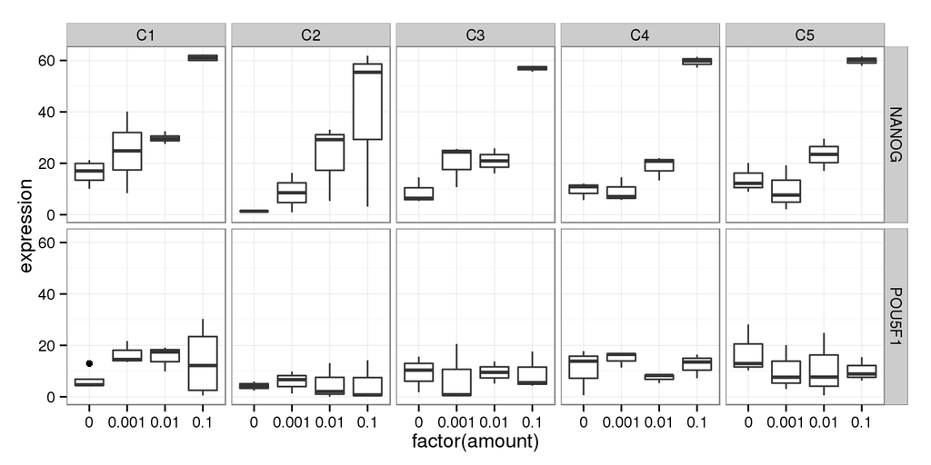

## Example - plot 2

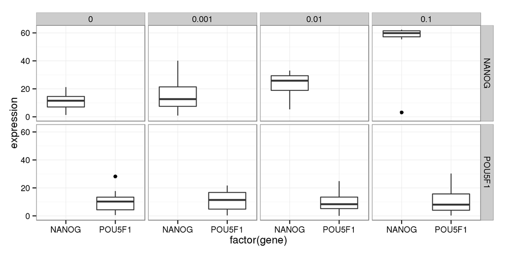

## Example - plot 3

Visualize empirical distribution of expression per gene across different drug amounts

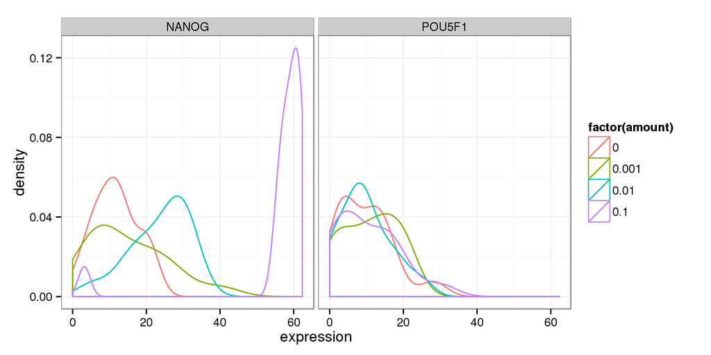

## References - other places to learn stuff

- [How to Transition from Excel to R](https://districtdatalabs.silvrback.com/intro-to-r-for-microsoft-excel-users)
- [Swirl Stats](http://www.swirlstats.com)
- [Data Analysis for Genomics](http://harvardx.harvard.edu/ph5251x-ph5258x-data-analysis-genomics)
- [Coursera Data Science](https://www.coursera.org/specialization/jhudatascience/1?utm_medium=courseDescripTop)
- [Introducing TidyR](http://blog.rstudio.org/2014/07/22/introducing-tidyr/)